# QTM 151 - Assignment 10

## Try to submit as an HTML file

Print your name below

```python
# Write your answer here
print("Peter Lin")
```

```
Peter Lin
```

Import the libraries "matplotlib.pyplot" and "pandas"

```python
# Write your answer here
import pandas as pd
import matplotlib.pyplot as plt
```

In this assigment you will work with data on exchange rates,  
for two currencies:

- 1 dollar (USD) to chinese yuan (RMB)
- 1 dollar (USD) to japanese yen (JPY).

For this lecture, you will need the material from  
Lecture 20 and 22.

(a) Import and parse dates

- Import the dataset "exchangerates.csv"
- Parse the "date_string" column with `pd.to_datetime()`
- To get full points, set the "format" option using wildcards as in Lecture 21.

```python
# Write your own code

df = pd.read_csv("data_raw/exchangerates.csv")
df.head()
```

|  | date_string | usd_to_rmb | usd_to_jpy |
| --- | --- | --- | --- |
| 0 | 1981, Friday, Jan 02 | 1.5341 | 202.50 |
| 1 | 1981, Monday, Jan 05 | 1.5418 | 199.05 |
| 2 | 1981, Tuesday, Jan 06 | 1.5264 | 199.70 |
| 3 | 1981, Wednesday, Jan 07 | 1.5264 | 201.05 |
| 4 | 1981, Thursday, Jan 08 | 1.5264 | 201.70 |

```python
df["date"] = pd.to_datetime(df["date_string"])

df["date_format"] = pd.to_datetime(df["date"], format = "%A, %Y-%m-%d")
df.head()
```

|  | date_string | usd_to_rmb | usd_to_jpy | date | date_format |
| --- | --- | --- | --- | --- | --- |
| 0 | 1981, Friday, Jan 02 | 1.5341 | 202.50 | 1981-01-02 | 1981-01-02 |
| 1 | 1981, Monday, Jan 05 | 1.5418 | 199.05 | 1981-01-05 | 1981-01-05 |
| 2 | 1981, Tuesday, Jan 06 | 1.5264 | 199.70 | 1981-01-06 | 1981-01-06 |
| 3 | 1981, Wednesday, Jan 07 | 1.5264 | 201.05 | 1981-01-07 | 1981-01-07 |
| 4 | 1981, Thursday, Jan 08 | 1.5264 | 201.70 | 1981-01-08 | 1981-01-08 |

(b) Plot multiple time series

- Create a line plot plot which has the "usd_to_rmb" and "usd_to_jpy" on the y-axis  
  and the date on the x-axis
- Label the x-axis, the y-axis, and the title
- Add a legend and set the names to "1 USD to RMB" and "1 USD to JPY"

Hint: See Lecture 22 for how to plot multiple columns  
Hint: Remember to include the legend names as a list `[...]`

[figure not shown]

```python
# Write your own code

df['usd_to_jpy_rescale']=df['usd_to_jpy']/20

df[["date","usd_to_rmb","usd_to_jpy_rescale"]].set_index("date").plot()
plt.xlabel("Time")
plt.ylabel("Exchange Rates")
plt.legend(["1 USD to RMB","1 USD to JPY"])
```

(c) Flag subset of data and plot

- Create a boolean vector (True/False) "bool_cond" which checks whether  
  "usd_to_jpy" is below 100
- Generate a line plot with the "usd_to_jpy" series, label the axes and the title
- Use the command `plt.fill_between()` as in Lecture 22 to create a shaded region  
  for time periods where "bool_cond" is true.

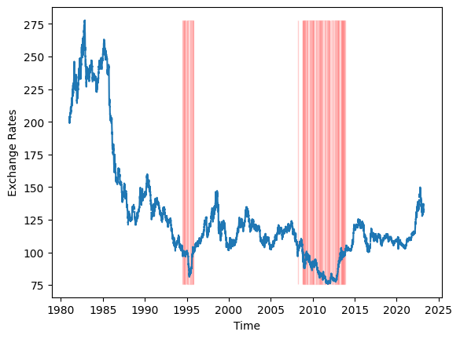

```python
# Write your own code
df['bool_jpy'] = df['usd_to_jpy'] < 100

plt.plot("date","usd_to_jpy",data = df)
plt.xlabel("Time")
plt.ylabel("Exchange Rates")

vec_y = df['usd_to_jpy']

plt.fill_between(x=df['date'], y1 = vec_y.min(), y2 = vec_y.max(), where = df['bool_jpy'], color = 'red', alpha = 0.1)
```

(d) Aggregate dataset by time period

```python
# Write your own code

month_config = pd.Grouper(key = 'date', freq = 'm')

usdjpy_std = df.groupby(month_config).agg(usdjpy_std = ('usd_to_jpy', 'std'))

usdjpy_std.head()
```

| date | usdjpy_std |
| --- | --- |
| 1981-01-31 | 1.882507 |
| 1981-02-28 | 2.114098 |
| 1981-03-31 | 1.620213 |
| 1981-04-30 | 1.890867 |
| 1981-05-31 | 2.857498 |

(e) Convert a dataset to long format

- Convert the currencies dataset to long format using the following inputs

```
var_name   = "type",
value_name = "exchange_rate",
id_vars    = "date",
value_vars = ["usd_to_rmb","usd_to_jpy"]
```

- Display the dataset

Hint: See Lecture 22 for details on `pd.melt()`

```python
# Write your own code

df_long = pd.melt(df, var_name = "type",value_name = "exchange_rate", id_vars    = "date", value_vars = ["usd_to_rmb","usd_to_jpy"])

df_long
```

|  | date | type | exchange_rate |
| --- | --- | --- | --- |
| 0 | 1981-01-02 | usd_to_rmb | 1.5341 |
| 1 | 1981-01-05 | usd_to_rmb | 1.5418 |
| 2 | 1981-01-06 | usd_to_rmb | 1.5264 |
| 3 | 1981-01-07 | usd_to_rmb | 1.5264 |
| 4 | 1981-01-08 | usd_to_rmb | 1.5264 |
| ... | ... | ... | ... |
| 22037 | 2023-03-27 | usd_to_jpy | 131.4900 |
| 22038 | 2023-03-28 | usd_to_jpy | 130.9700 |
| 22039 | 2023-03-29 | usd_to_jpy | 132.6900 |
| 22040 | 2023-03-30 | usd_to_jpy | 132.7100 |
| 22041 | 2023-03-31 | usd_to_jpy | 132.7500 |

22042 rows × 3 columns